# Project 3 - Pandas & Seaborn 201

- Your Name Here: Anthony Ayala
- WFU Email Address: ayalax19@wfu.edu
- Submission Date: 07/30/23

# Instructions

1. Download the notebook `pandas_seaborn_201_yournamehere.ipynb` and the dataset `Customer Churn.csv` from the course website.
2. Open the notebook on your local computer; Or upload and open it in Google Colab.
3. Replace the placeholder text above with your name, email address, and submission date.
4. This is a simple project made up of mini-tasks. Simply write the code to answer the question, and be sure to display your results!
5. Please submit your notebook in **HTML** on Canvas.

# Who is likely to churn?

You are competing for a job as a business analyst working for a mobile phone company like Verizon, Mint Mobile, or AT&T. As part of the interview process, you have been tasked with exploring which customers are likely to “churn”.

**Customer churn**, also known as customer attrition, occurs when customers stop doing business with a company or stop using a company’s services. The company uses an annual valuation of $1200 per customer so if a customer churns (i.e. switches service) they are out a considerable sum of money.

The company believes...

- Churn is influenced by the *network speed* (5G or 4G LTE) and the *phone model*
- Customers who opt for *paperless billing* are less likely to churn

[figure not shown]

# Some Expectations

- Think about the business problem and how your analysis can address the problem
- Make sure **any chart** you create has: **title, x & y axis labels, and a description of why someone would care to look at it**
- Make sure you spend time understanding what your code does.

## Task 0. Load libraries

Load the following libraries, you may need to install them first!

- Data Manipulation: `pandas`, `numpy`
- Data Visualization：`seaborn`, `matplotlib.pyplot`
- Other: `warnings` (ignore warning messages)

```python
import pandas as pd
import numpy as np
import seaborn as sns
import matplotlib.pyplot as plt
```

```python
import warnings
warnings.filterwarnings('ignore')
```

```python
from google.colab import drive
drive.mount('/content/drive')
```

```python
df_churn = pd.read_csv('/content/drive/MyDrive/Project HW Files/Customer Churn.csv')
```

## Task 1. Stage

1. Use `pd.read_csv()` to read in the `Customer Churn.csv` data file, store it as a data frame named `"df_churn"`
2. Display the first 5 records

   > Tip: For wide data, try `df.head().T` to display all the columns
3. Check its shape and respective data types using `info()`

```python
# Display the first five records with the function head()
df_churn.head().T

# We use .T for when we have wide data
```

|  | 0 | 1 | 2 | 3 | 4 |
| --- | --- | --- | --- | --- | --- |
| monthly_minutes | 22604.0 | 17059.0 | 25848.0 | 22080.0 | 23871.0 |
| customer_service_calls | 2.0 | 2.0 | 2.0 | 3.0 | 3.0 |
| streaming_minutes | 26525.0 | 16887.0 | 26783.0 | 23649.0 | 7705.0 |
| total_billed | 285.0 | 201.0 | 264.0 | 274.0 | 236.0 |
| prev_balance | 47.0 | 45.0 | 44.0 | 49.0 | 61.0 |
| late_payments | 5.0 | 5.0 | 6.0 | 6.0 | 5.0 |
| ip_address_asn | 16767.0 | 53966.0 | 19278.0 | 16680.0 | 51308.0 |
| phone_area_code | 253.0 | 241.0 | 232.0 | 236.0 | 243.0 |
| customer_reg_date | 2020-04-15 | 2020-04-12 | 2020-02-22 | 2020-08-05 | 2019-11-16 |
| email_domain | yahoo.com | gmail.com | gmail.com | yahoo.com | gmail.com |
| phone_model | Samsung Galaxy S20 Ultra | Samsung Galaxy S10 / S10 Plus | OnePlus 8 Pro | iPhone XS | Samsung Galaxy S10e |
| billing_city | West Shannonside | Jacquelinetown | North Luke | West Coreyberg | Joshuachester |
| billing_postal | 39120.0 | 24469.0 | 68797.0 | 19352.0 | 46999.0 |
| billing_state | Rhode Island | Alaska | North Dakota | Nebraska | Pennsylvania |
| partner | Yes | Yes | Yes | No | Yes |
| phone_service | Yes | Yes | Yes | Yes | Yes |
| multiple_lines | No | Yes | Yes | No | Yes |
| streaming_plan | 3GB | Unlmited | Unlmited | 3GB | 3GB |
| mobile_hotspot | Yes | No | No | No | No |
| wifi_calling_text | No | Yes | Yes | No | Yes |
| online_backup | Yes | Yes | No InternetService | Yes | Yes |
| device_protection | O | S | V | O | C |
| number_phones | 6.0 | 5.0 | 5.0 | 6.0 | 7.0 |
| contract_code | B | S | W | W | W |
| currency_code | usd | eur | cad | cad | cad |
| maling_code | H | V | R | N | V |
| paperless_billing | No | Yes | Yes | No | Yes |
| payment_method | Mailed Check | Mailed Check | Credit Card | Mailed Check | Electronic Check |
| customer_id | 1-136-08562-9.1 | 0-384-11264-1.2 | 0-08-151665-7.3 | 0-02-200816-0.4 | 0-87476-135-2.5 |
| billing_address | 5592 Gill Pine Suite 387 | 5806 Kathleen Mount Suite 186 | 5037 Allen Square Apt. 727 | 841 Griffin Route Suite 824 | 46185 Mejia Manor Apt. 558 |
| gender | Female | Male | Male | Female | Male |
| network_speed | 5G | 5G | 5G | 5G | 4Glte |
| senior_citizen | 1.0 | 0.0 | 1.0 | 0.0 | 1.0 |
| churn | 0 | 0 | 0 | 0 | 0 |

```python
# Check the shape with info()
df_churn.info()

# Common data types are objects (22) and floats (11).
# Seems that we have very few null values
```

```
<class 'pandas.core.frame.DataFrame'>
RangeIndex: 90901 entries, 0 to 90900
Data columns (total 34 columns):
 #   Column                  Non-Null Count  Dtype
---  ------                  --------------  -----
 0   monthly_minutes         90881 non-null  float64
 1   customer_service_calls  90879 non-null  float64
 2   streaming_minutes       90879 non-null  float64
 3   total_billed            90867 non-null  float64
 4   prev_balance            90879 non-null  float64
 5   late_payments           90881 non-null  float64
 6   ip_address_asn          90884 non-null  float64
 7   phone_area_code         90873 non-null  float64
 8   customer_reg_date       90874 non-null  object
 9   email_domain            90873 non-null  object
```

[output cut: 26 more lines]

## Task 2. Cleansing & Profiling (Part I)

Our dataset contains in following varibales:

- **monthly_minutes**: Monthly usage in minutes
- **customer_service_calls**: # of calls to customer services
- **streaming_minutes**: Monthly streaming in minutes
- **total_billed**: Total bill amount in $
- **prev_balance**: Previous balance statement
- **late_payments**: # of late payments
- **ip_address_asn**: IP address
- **phone_area_code**: Phone area code
- **customer_reg_date**: Customer registration date
- **email_domain**: Customer email
- **phone_model**: Phone model
- **billing_city**: Billing city
- **billing_postal**: Billing zip code
- **billing_state**: Billing state
- **partner**: A partnering company who helped initiate the phone contract
- **phone_service**: phone service
- **multiple_lines**: multiple lines
- **streaming_plan**: streaming plan
- **mobile_hotspot**: mobile hotspot
- **wifi_calling_text**: wifi calling text
- **online_backup**: online backup
- **device_protection**: device protection
- **number_phones**: # of phones obtained
- **contract_code**: code of the contract with the company
- **currency_code**: payment currency
- **maling_code**: mailing code
- **paperless_billing**: opt for paperless billing
- **payment_method**: payment method
- **customer_id**: customer id
- **billing_address**: full billing address
- **gender**: gender
- **network_speed**: network speed
- **senior_citizen**: if the customer is a senior citizen
- **churn**: if the customer churned
1. Let's begin with cleaning the data types:
- Correct the data types for variable `billing_postal`, `phone_area_code`, `ip_address_asn` to **'object'**

  > May use the code like this:

  > ```
  > df['variable'] = df['variable'].astype('object')
  > ```

- Correct the data type of variable `churn`, `senior_citizen` to **'bool'**
- Correct the data type of variable `customer_reg_date` to **'datetime64'**

  > Hint: `pd.to_datetime()`
1. Select all **numerical variables** using `select_dtypes()`, put their column names in a `list`

   > Hint: `df.select_dtypes(include=['int64', 'float64']).columns.to_list()`
2. For Loop Automation: Fire up a for loop that creates a histogram for each variable using `sns.histplot()`, with `hue='churn'`.

   > Hint: A good reference is [here](https://colab.research.google.com/drive/193chykBcPCS1AJ4u73cblqY_HbvWW86C?usp=sharing).
3. **Articulate 3 key findings you derived from the generated plots**

```python
# Correct the data types
df_churn['billing_postal'] = df_churn['billing_postal'].astype('object')
df_churn['phone_area_code'] = df_churn['phone_area_code'].astype('object')
df_churn['ip_address_asn'] = df_churn['ip_address_asn'].astype('object')
df_churn['churn'] = df_churn['churn'].astype('bool')
df_churn['senior_citizen'] = df_churn['senior_citizen'].astype('bool')
df_churn['customer_reg_date'] = pd.to_datetime(df_churn['customer_reg_date'])
df_churn.dtypes
```

```
monthly_minutes                  float64
customer_service_calls           float64
streaming_minutes                float64
total_billed                     float64
prev_balance                     float64
late_payments                    float64
ip_address_asn                    object
phone_area_code                   object
customer_reg_date         datetime64[ns]
email_domain                      object
phone_model                       object
billing_city                      object
billing_postal                    object
billing_state                     object
partner                           object
phone_service                     object
multiple_lines                    object
streaming_plan                    object
mobile_hotspot                    object
wifi_calling_text                 object
online_backup                     object
device_protection                 object
number_phones                    float64
contract_code                     object
currency_code                     object
maling_code                       object
paperless_billing                 object
payment_method                    object
customer_id                       object
billing_address                   object
gender                            object
network_speed                     object
senior_citizen                      bool
churn                               bool
dtype: object
```

```python
# Select all numerical variables using select_dtypes(), put their column names in a list
numeric_vars = df_churn.select_dtypes(include=['int64', 'float64']).columns.to_list()
numeric_vars

# We could have also done a for loop to print the list
# for column in numerics_vars:
#   print(column)
```

```
['monthly_minutes',
 'customer_service_calls',
 'streaming_minutes',
 'total_billed',
 'prev_balance',
 'late_payments',
 'number_phones']
```

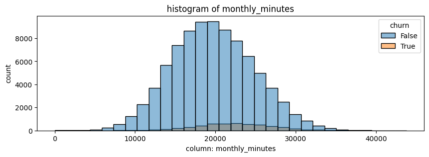

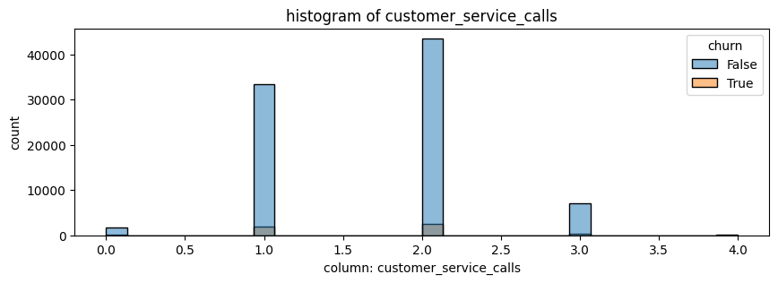

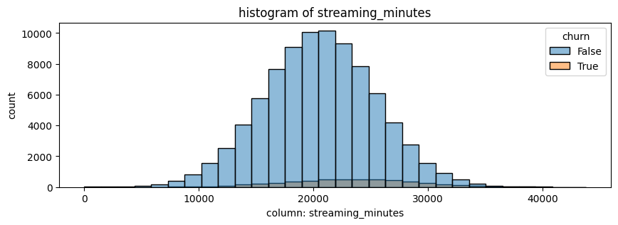

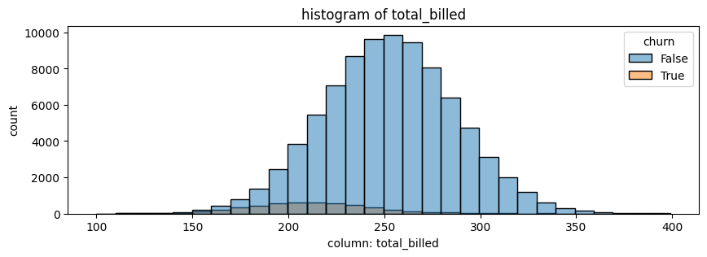

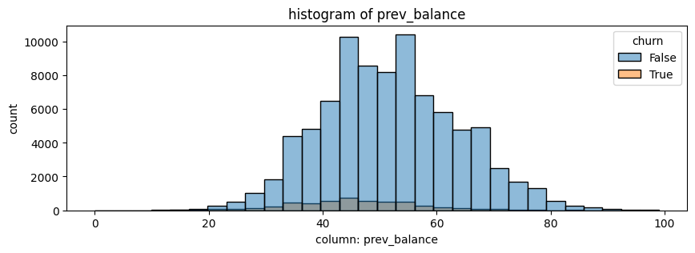

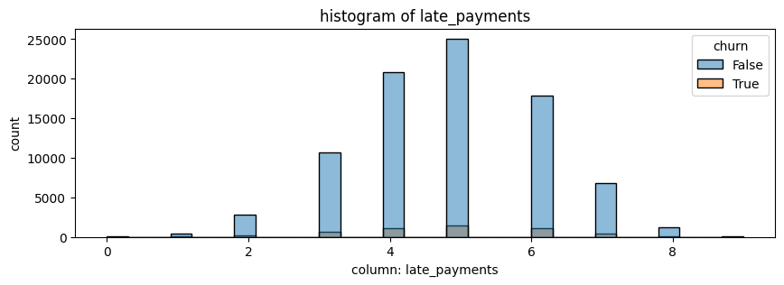

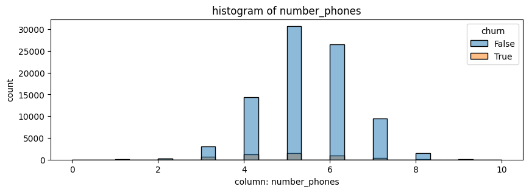

```python
# For Loop Automation: Fire up a for loop that creates a histogram for each variable using sns.histplot(), with hue='churn'.
for column in numeric_vars:
  #column = 'monthly_minutes, customer_service_calls, streaming_minutes, total_billed, prev_balance, late_payments, number_phones'
  plt.figure(figsize=(10,3))
  sns.histplot(data=df_churn, x=column, hue='churn', bins=30)
  plt.title(f"histogram of {column}")
  plt.xlabel(f"column: {column}")
  plt.ylabel("count")
  plt.show();
```

Your Findings:

- Majority of phone usage (number of minutes used to call and to stream) is captured from 10,000 to 30,000 and has a unimodal shape. It looks quite symmetric and has a center of roughly 20,000 minutes.
- Churn does not seem to be a huge issue in the numeric variable columns. It seems to have two types of patterns for previous balance and total billed where churn is present and at its highest at the lower values. While for monthly minutes and minutes streamed is at its highest and present at the higher values.
- It seems quite common for there to be 4 to 6 phones and 4 to 6 late payments.

## Task 3. Cleansing & Profiling (Part II)

1. Start by selecting all **categorical and boolean variables** using `select_dtypes()`, put their column names in a `list`

   > Hint: include=['object','bool']
2. Remove the following variables from the list: `customer_id`, `billing_address`, `billing_city`, `billing_state`, `billing_postal`, `phone_area_code`, `ip_address_asn`

   > Hint: `my_list.remove()`
3. Fire up a for loop which creates a countplot for each variable using `sns.countplot()` - Make sure the bars are ordered for easy comparison

   > Hint: `order=df_churn[column].value_counts().index`
4. **Articulate 3 key observations you derived from the generated plots**

```python
# Start by selecting all categorical and boolean variables using select_dtypes, put their column names in a list
obj_bool_vars = df_churn.select_dtypes(include=['object', 'bool']).columns.to_list()
obj_bool_vars
```

```
['ip_address_asn',
 'phone_area_code',
 'email_domain',
 'phone_model',
 'billing_city',
 'billing_postal',
 'billing_state',
 'partner',
 'phone_service',
 'multiple_lines',
 'streaming_plan',
 'mobile_hotspot',
 'wifi_calling_text',
 'online_backup',
 'device_protection',
 'contract_code',
 'currency_code',
 'maling_code',
 'paperless_billing',
 'payment_method',
 'customer_id',
 'billing_address',
 'gender',
 'network_speed',
 'senior_citizen',
 'churn']
```

```python
# Let's create a list of the columns we want to remove and then use set difference
# Then we will assign the final list
remove = df_churn[['customer_id', 'billing_address', 'billing_city', 'billing_state', 'billing_postal', 'phone_area_code', 'ip_address_asn']]
obj_vars_list = list(set(obj_bool_vars)-set(remove))
obj_vars_list
```

```
['currency_code',
 'network_speed',
 'paperless_billing',
 'maling_code',
 'email_domain',
 'phone_service',
 'multiple_lines',
 'wifi_calling_text',
 'device_protection',
 'partner',
 'gender',
 'payment_method',
 'contract_code',
 'senior_citizen',
 'streaming_plan',
 'churn',
 'online_backup',
 'phone_model',
 'mobile_hotspot']
```

```python
# We can double check the columns by applying the query result (remove), use isin(remove), and then check the columns with .columns
df_churn[obj_vars_list].isin(remove).columns
```

```
Index(['currency_code', 'network_speed', 'paperless_billing', 'maling_code',
       'email_domain', 'phone_service', 'multiple_lines', 'wifi_calling_text',
       'device_protection', 'partner', 'gender', 'payment_method',
       'contract_code', 'senior_citizen', 'streaming_plan', 'churn',
       'online_backup', 'phone_model', 'mobile_hotspot'],
      dtype='object')
```

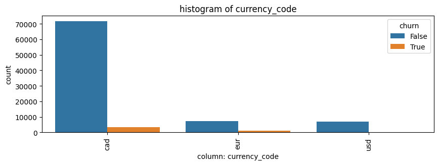

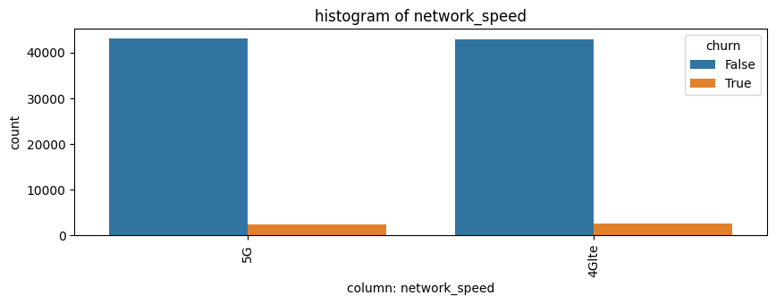

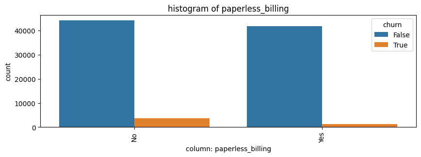

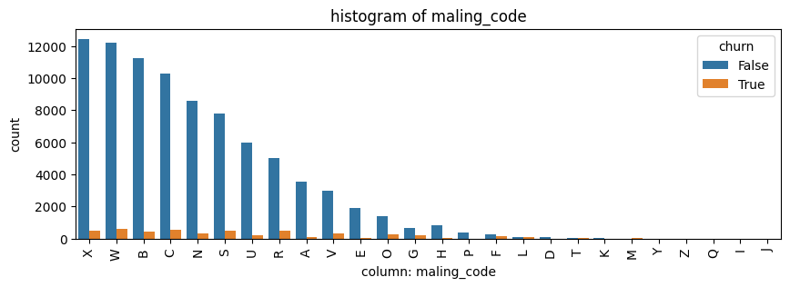

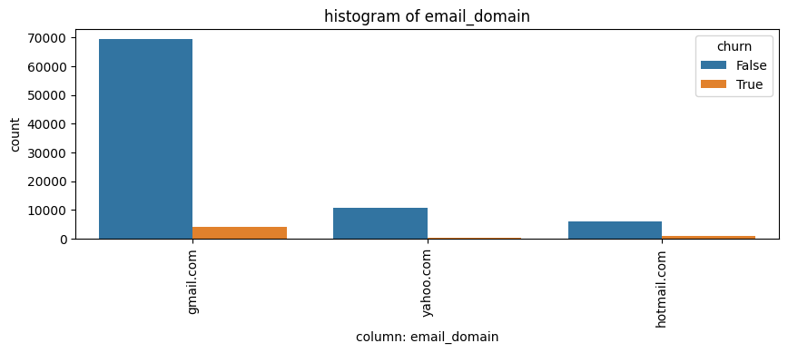

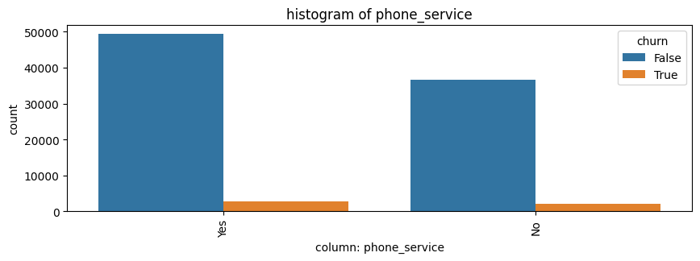

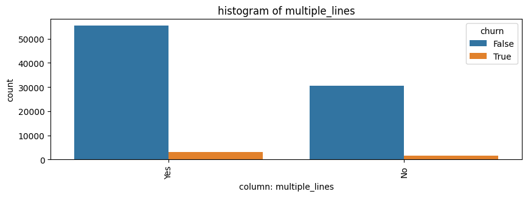

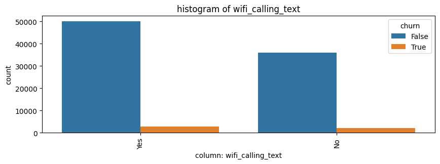

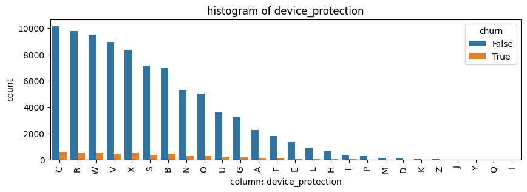

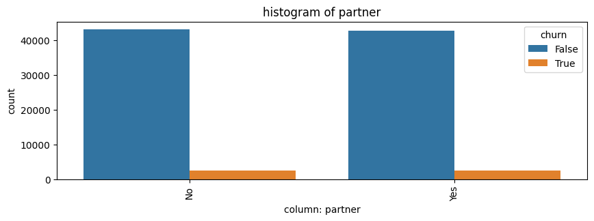

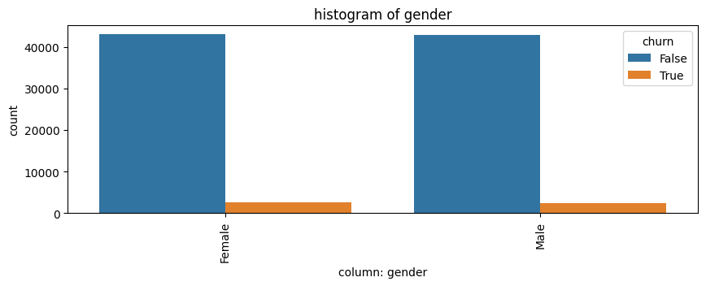

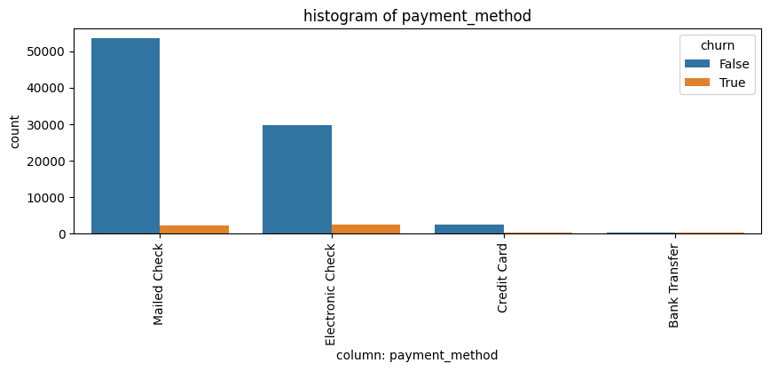

[7 more figures not shown]

```python
# Fire up a for loop which creates a countplot for each variable using sns.countplot() - Make sure the bars are ordered for easy comparison
# Hint: order=df_churn[column].value_counts().index
for column in obj_vars_list:
  # column = 'senior citizen, gender, network speed, phone service, email domain, currency code, wifi calling text, phone model, contract code,
  # mobile hotspot, paperless billing, payment method, partner, mailing code, device protection, churn, streaming plan, multiple lines, online backup.
  plt.figure(figsize=(10,3))
  sns.countplot(data=df_churn,
               x=column,
               hue='churn',
               order=df_churn[column].value_counts().index)
  plt.title(f"histogram of {column}")
  plt.xlabel(f"column: {column}")
  plt.xticks(rotation=90)
  plt.ylabel("count")
  plt.show();
```

Your Findings:

- Again, it seems that customer churn doesn't seem to have a huge impact on the the variables in this dataset. Also, it's important to note that in the histogram plot of churn, the frequency of churn is really low so it must be the case that it does not play a huge role. It might also be the case that a lot of the customers are satisified and stay with their companies due to go business practices and incentives.
- Lots of customers use mailed checks and electronic checks as their preferred method of payment, which I would think that credit cards would be more common as how easy and how popular they have become as a payment method.
- We can assume there is a lot of Canadian customers or consuming Canadian goods and services as the number one currency code is Canadian. So we will expecting to see a lot of phone lines like Mint Mobile, Telus, Rogers, etc.